# package::shapFlex Consistency

Nick Redell, nickredell@hotmail.com

2019-04-26

# Purpose

- The goal of this vignette is to show how the stochastic Shapley values produced from `shapFlex` are correlated with the exact Shapley values computed in the Python **shap** package using the implentation discussed **[here](https://arxiv.org/abs/1802.03888)**.
- Treating the `shap`-based Shapley values as the ground truth, we would like to see the sampling based method in `shapFlex` reproduce the ground truth values–within sampling variability–to give us confidence in our shapFlex implentation.
- We’ll use **[catboost’s](https://catboost.ai/)** R package which has a port of `shap` found in the `catboost.get_feature_importance()` function.
- While `shap` returns Shapley values almost instanteously and should be the preferred method when modeling with boosted trees, **this vignette demonstrates that the more generic `shapFlex` implementation can be applied to boosted tree models, non-boosted tree models, and ensembles of machine learning models and return reliable results**.

# Example

## Load packages and data.

```r
library(randomForest)
library(dplyr)
library(ggplot2)
library(catboost)  # version 0.14.2
library(shapFlex)  # version 0.1.0

data("imports85", package = "randomForest")
data <- imports85

data <- data[, -2]  # this column has excessive missing data.
data <- data[complete.cases(data), ]
row.names(data) <- 1:nrow(data)  # re-index for simplicity.

outcome_col <- which(names(data) == "price")
outcome_name <- names(data)[outcome_col]
```

## Model Training

- The accuracy of the model isn’t entirely important because we’re interested in comparing Shapley values.

```r
data_pool <- catboost.load_pool(data = data[, -outcome_col],
                                label = as.vector(data[, outcome_col]))

set.seed(224)
model_catboost <- catboost.train(data_pool,  NULL, params = list(loss_function = 'RMSE',
                                                                 iterations = 100))
```

## shapFlex Shapley Values

### Prediction Function Wrapper

- Our shapFlex-required user-defined prediction function that takes 2 positional arguments and returns a 1-column data.frame. See the package overview vignette for more info.
- Note the creation of the catboost-specific data format inside the function.

```r
predict_ensemble <- function(models, data, ...) {

  data_pool <- catboost.load_pool(data = data)  # create catboost-usable data.

  data_pred <- data.frame("y_pred" = catboost.predict(models[[1]], data_pool))

  return(data_pred)
}
```

### shapFlex::shapFlex()

```r
# A list of data.frame(s) of model features suitable for the user-defined predict function(s).
data_list <- list(data[, -(outcome_col), drop = FALSE])
# Dataset row numbers or indicies.
explain_instances <- 1:nrow(data)
# Are the instances to explain row numbers/indices or row names ('row_name') in the input data?
explain_instance_id <- "row_index"
# A list of of model objects. Nested lists of length(data_list) are needed if length(data_list) > 1.
model_list <- list(model_catboost)
# A list of length 1 vectors with length(prediction_functions) == length(data_list).
predict_functions <- list("predict_ensemble")
# The number of randomly selected dataset rows used to calculate the feature-level Shapley values.
sample_size <- 200
# Number of cores to use in parallel::mclapply(); limited to 1 on Windows OS.
n_cores <- if (Sys.info()["sysname"] == "Windows") {1} else {parallel::detectCores() - 1}

explained_instances <- vector("list", length(explain_instances))

set.seed(224)
for (i in seq_along(explain_instances)) {

  explained_instances[[i]] <- shapFlex::shapFlex(data = data_list,
                                                 explain_instance = explain_instances[i],  # loop
                                                 explain_instance_id = explain_instance_id,
                                                 models = model_list,
                                                 predict_functions = predict_functions,
                                                 sample_size = sample_size,
                                                 n_cores = n_cores)
}

# Return the list of instance-level results as a data.frame.
data_shap <- dplyr::bind_rows(explained_instances)
data_shap <- dplyr::filter(data_shap, feature_name != "intercept")
```

## Catboost Shapley Values

```r
data_shap_catboost <- catboost.get_feature_importance(model_catboost, pool = data_pool,
                                                      type = "ShapValues")
data_shap_catboost <- as.data.frame(data_shap_catboost)
data_shap_catboost$explained_instance <- 1:nrow(data_shap_catboost)
data_shap_catboost <- tidyr::gather(data_shap_catboost, key = "feature_name",
                                    value = "shap_effect_catboost", -explained_instance)
```

# Results

## Shapley Value Comparison

- For **20 out of 23 model predictors** (excluding “make” which was not used in the model), the **correlation** between the Shapley values produced by the exact method in `shap` and the stochastic method in `shapFlex` was **> .90** (see table and plot below).
- Interestingly, the large discrepancy in Shapley values for the ‘fuelType’ predictor are present only for diesel cars. This binary predictor is 90% one value, gasoline cars, so it’s likely that a higher sample size in `shapFlex` would bring the diesel cars into alignment with the values from `shap`.

```r
data_cor <- dplyr::inner_join(data_shap, data_shap_catboost,
                              by = c("explained_instance", "feature_name"))

data_cor <- data_cor %>%
  dplyr::group_by(feature_name) %>%
  dplyr::summarise("cor_coef" = round(cor(shap_effect, shap_effect_catboost), 2))
```

```r
DT::datatable(data_cor, colnames = c('Feature', 'Correlation'))
```

|  | Feature | Correlation |
| --- | --- | --- |
| 1 | aspiration | 0.92 |
| 2 | bodyStyle | 0.97 |
| 3 | bore | 0.97 |
| 4 | cityMpg | 0.99 |
| 5 | compressionRatio | 0.99 |
| 6 | curbWeight | 0.98 |
| 7 | driveWheels | 0.99 |
| 8 | engineLocation | 0.96 |
| 9 | engineSize | 0.99 |
| 10 | engineType | 0.95 |

[output cut: 14 more lines]

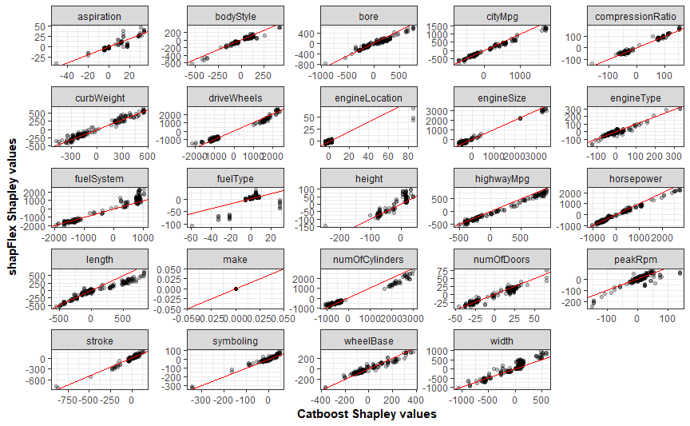

```r
data_plot <- dplyr::inner_join(data_shap, data_shap_catboost, by = c("explained_instance", "feature_name"))

p <- ggplot(data_plot, aes(shap_effect_catboost, shap_effect))
p <- p + geom_point(alpha = .25)
p <- p + geom_abline(color = "red")
p <- p + facet_wrap(~ feature_name, scales = "free")
p <- p + theme_bw() + xlab("Catboost Shapley values") + ylab("shapFlex Shapley values") +
  theme(axis.title = element_text(face = "bold"))
p
```